# Project: Investigate a Dataset - [tmdb-movies]

### Research Question 2 (Which are movies with the highest profit and lowest profit?

### What is the top 10 most profitable movies?)

```python
# Which are movies with the highest profit and lowest profit?
max_profit = tmdb_df['profit'].max()
tmdb_df.loc[tmdb_df['profit'] == max_profit, 'original_title']
```

```
1386    Avatar
Name: original_title, dtype: object
```

```python
# Which are movies with the lowest profit ?
min_profit = tmdb_df['profit'].min()
tmdb_df.loc[tmdb_df['profit'] == min_profit, 'original_title']
```

```
2244    The Warrior's Way
Name: original_title, dtype: object
```

```python
# What is the top 10 most profitable movies?
```

[figure not shown]

```python
plt.figure(figsize=(20,10));
ds = tmdb_df[['original_title','profit']].sort_values('profit', ascending=False).head(10)
sns.barplot(x='original_title', y='profit',data=ds,color='Blue')
plt.title('Top 10 most profitable movies',fontsize=25)
plt.xlabel('Original_title',fontsize=15)
plt.ylabel('Revenue',fontsize=15)
plt.xticks(rotation=90)
plt.show();
```

## As we can see, the movie ‘Avatar’, directed by James Cameron, earned the highest profit of all.”

```python
# Which has been the most popular genres over the years?
```

```python
du=tmdb_df.genres.str.get_dummies(sep='|')
du1=du.sum().reset_index()
```

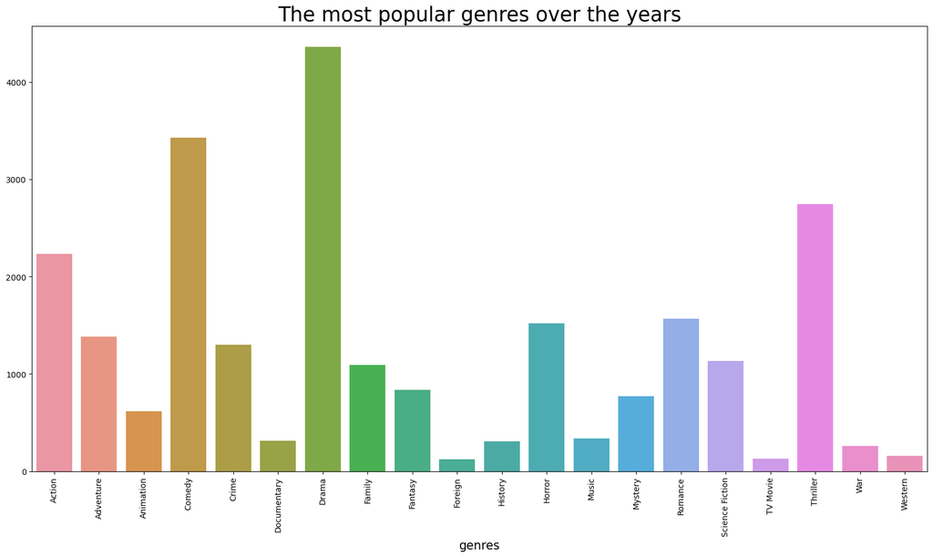

```python
plt.figure(figsize=(20,10))
sns.barplot(x=du.columns, y=du.sum(), data=du1)
plt.title('The most popular genres over the years', fontsize=25)
plt.xlabel('genres', fontsize=15)
plt.ylabel('')
plt.xticks(rotation=90)
plt.show()
```

## Submitting your Project

> **Tip**: Before you submit your project, you need to create a .html or .pdf version of this notebook in the workspace here. To do that, run the code cell below. If it worked correctly, you should get a return code of 0, and you should see the generated .html file in the workspace directory (click on the orange Jupyter icon in the upper left).

> **Tip**: Alternatively, you can download this report as .html via the **File** > **Download as** submenu, and then manually upload it into the workspace directory by clicking on the orange Jupyter icon in the upper left, then using the Upload button.

> **Tip**: Once you've done this, you can submit your project by clicking on the "Submit Project" button in the lower right here. This will create and submit a zip file with this .ipynb doc and the .html or .pdf version you created. Congratulations!

```python
from subprocess import call
call(['python', '-m', 'nbconvert', 'Investigate_a_Dataset.ipynb'])
```

```
1
```